# Reproducible analysis of AMR subset in TGP

```r
library(knitr)
library(genio)
library(ggtree)
library(popkin)
library(BEDMatrix)
library(seriation)
library(superadmixture)
library(tidyverse)

# for plotting
library(ggplot2)
library(grid)
library(gridGraphics)
library(ggplotify)
library(ggpubr)
library(cowplot)
library(patchwork)
library(latex2exp)
```

# 1 Data Preprocessing

In this document, we demonstrate our procedures for analysis of AMR subset of 1000 Genomes phase 3. The raw TGP phase 3 is available at the [FTP site](https://ftp.1000genomes.ebi.ac.uk/vol1/ftp/data_collections/1000G_2504_high_coverage/working/20220422_3202_phased_SNV_INDEL_SV/), attributed to [Byrska-Bishop et al. (2022)](https://doi.org/10.1016/j.cell.2022.08.004). Here we start with the assembled version of TGP, provided by the [PLINK](https://www.cog-genomics.org/plink/2.0/resources). PLINK hosts the assembled data at the following dropbox link:

- `.pgen` file: https://www.dropbox.com/s/j72j6uciq5zuzii/all_hg38.pgen.zst?dl=1
- `.pvar` file: https://www.dropbox.com/s/vx09262b4k1kszy/all_hg38.pvar.zst?dl=1
- `.psam` file: https://www.dropbox.com/s/2e87z6nc4qexjjm/hg38_corrected.psam?dl=1

The associated annotations can be found at the FTP site:

- Pedigree information: http://ftp.1000genomes.ebi.ac.uk/vol1/ftp/data_collections/1000G_2504_high_coverage/working/1kGP.3202_samples.pedigree_info.txt
- Population information: http://ftp.1000genomes.ebi.ac.uk/vol1/ftp/data_collections/1000G_2504_high_coverage/20130606_g1k_3202_samples_ped_population.txt

We use `PLINK2` and `zstd` for data preprocessing. The `PLINK2` software can be downloaded from this [webpage](https://www.cog-genomics.org/plink/2.0/). The `ztsd` is hosted at the [github](https://github.com/facebook/zstd.git), and can downloaded and installed through the following commands.

```bash
git clone https://github.com/facebook/zstd.git
cd zstd
make install
```

We download and unzip the assembled TGP data from the dropbox stated above. We create a folder called `rawdata` to host the downloaded raw data and pre-processed data.

```bash
mkdir -p rawdata && cd $_

zstd=<PATH_TO_ZSTD_EXECUTABLE>

## download `.pgen` file
wget "https://www.dropbox.com/s/j72j6uciq5zuzii/all_hg38.pgen.zst?dl=1"
mv "all_hg38.pgen.zst?dl=1" "all_phases3.pgen.zst"
./$zstd -d all_phases3.pgen.zst
rm all_phases3.pgen.zst

## download `.pvar` file
wget "https://www.dropbox.com/s/vx09262b4k1kszy/all_hg38.pvar.zst?dl=1"
mv "all_hg38.pvar.zst?dl=1" "all_phases3.pvar.zst"

## download `.psam` file
wget "https://www.dropbox.com/s/2e87z6nc4qexjjm/hg38_corrected.psam?dl=1"
mv "hg38_corrected.psam?dl=1" "all_phases3.psam"
```

This step serves to assign unique variant IDs to each locus.

```bash
PLINK2=<PATH_TO_PLINK2_EXECUTABLE>

./$PLINK2 \
    --pfile all_phases3 vzs \
    --set-missing-var-ids '@:#' \
    --allow-extra-chr \
    --make-just-pvar zs \
    --out all_phases3_uniq

mv all_phases3.pvar.zst all_phases3.orig.pvar.zst
mv all_phases3_uniq.pvar.zst all_phases3.pvar.zst
rm all_phases3_uniq.log
rm all_phases3.orig.pvar.zst
```

This step serves to preserve loci that:

1. are autosomal, biallelic SNPs (model assumption)
2. are variant in the Yoruba samples (code YRI), and
3. have unique IDs

```bash
grep -E '\#|YRI' all_phases3.psam > all_phases3_YRI.psam

./$PLINK2 \
    --pfile all_phases3 vzs \
    --rm-dup exclude-all \
    --allow-extra-chr \
    --write-snplist zs \
    --out nodups

./$PLINK2 \
    --pfile all_phases3 vzs \
    --keep all_phases3_YRI.psam \
    --extract nodups.snplist.zst \
    --autosome \
    --allow-extra-chr \
    --snps-only just-acgt \
    --max-alleles 2 \
    --keep-founders \
    --mac 1 \
    --write-snplist zs \
    --out YRI

rm YRI.log
rm all_phases3_YRI.psam
rm nodups.log
rm nodups.snplist.zst
```

This step serves to preserve individuals marked as “AMR”.

```bash
grep -E '\#|AMR' all_phases3.psam > all_phases3_AMR.psam

./$PLINK2 \
    --pfile all_phases3 vzs \
    --keep all_phases3_AMR.psam \
    --extract YRI.snplist.zst \
    --keep-founders \
    --allow-extra-chr \
    --mac 1 \
    --make-bed \
    --out amr


rm YRI.snplist.zst
rm all_phases3_AMR.psam
rm amr.log
```

Then we add subpopulation labels to FAM files.

```bash
awk -F" " '{
  if (NR == FNR) population[$1]=$6;
  else print population[$2],$2,$3,$4,$5,$6;
}' all_phases3.psam amr.fam > amr.fam.NEW

mv amr.fam.NEW amr.fam
```

This step serves to preserve loci that:

1. have MAF >= 0.01
2. are in approximate linkage equilibrium with each other

```bash
./$PLINK2 \
    --bfile amr \
    --make-bed \
    --out amr_maf_0.01 \
    --maf 0.01

## this command determines the loci to keep or exclude
./$PLINK2 --bfile amr_maf_0.01 --indep-pairwise 1000kb 0.3 --out amr_maf_0.01

## this actually filters the data
./$PLINK2 \
    --bfile amr_maf_0.01 \
    --extract amr_maf_0.01.prune.in \
    --make-bed \
    --out amr_final

rm amr.{bed,bim,fam}
rm amr_maf_0.01.{bed,bim,fam,log,prune.in,prune.out}
rm amr_final.log
```

# 2 Estimating individual-level coancestry

In the following sections, the intermediate data will be stored at the `rdata` folder.

Here we demonstrate how to estimate the individual-level coancestry $\boldsymbol{\Theta}$ according to the Ochoa-Storey (OS) method by `popkin` package. So here we only presents the codes but not running them. We provide the pre-computed coancestry at `rdata/coanc_os.rda`. It doesn’t make sense to use the TGP sub-populations here, so we’ll ignore them as we estimate the kinship matrix. As a first pass, let’s order the individuals grouping by sub-population.

```r
X    <- BEDMatrix::BEDMatrix("rawdata/amr_final", simple_names = TRUE)
fam  <- genio::read_fam( "rawdata/amr_final")

# Reorder individuals by the sub-population order
subpop_order <- c('PUR', 'CLM', 'PEL', 'MXL')
index        <- order(factor(fam$fam, level = subpop_order))
fam          <- fam[index, ]
X            <- X[index, ]

# Estimate the Ochoa-Storey kinship
obj         <- popkin::popkin_A(t(X))
A_min       <- popkin::popkin_A_min_subpops(obj$A)
kinship_os  <- 1 - obj$A / A_min
```

Here we call the `seriate` function from the package `seriation` to order individuals. This function arranges individuals by grouping the most similar closer to each other, and the most dissimilar far from each other. In terms of the kinship matrix, this approach will concentrate the largest values on the diagonal and the lowest values farthest from the diagonal.

```r
order_seriate <- function(kinship) {
  distance <- -kinship
  distance <- distance - min(distance)
  distance <- as.dist(distance)

  # perform desired optimization
  seriation_object <- seriation::seriate(distance, method = 'ARSA')
  index <- seriation::get_order(seriation_object)

  y <- diag(kinship)[index]
  x <- 1:length(y)
  m <- coef(lm(y ~ x))[2]
  if (m < 0) {
    index <- rev(index)
  }

  return(index)
}

index      <- order_seriate(kinship_os)
kinship_os <- kinship_os[index, index]
fam        <- fam[index, ]
X          <- X[index, ]
```

It should noted that the `popkin` function returns the kinship coefficients instead of the coancestry coefficients. Therefore, we use the `inbr_diag` function in the `popkin` package to map kinship coefficients $\phi_{jk}$’s to coancestry coefficients $\theta_{jk}$’s:

$$\theta_{jk} =
\begin{cases}
2\phi_{jk} - 1 & j = k \\
\phi_{jk} &j \neq k
\end{cases}.$$

```r
coanc_os   <- popkin::inbr_diag(kinship_os)
coanc_os   <- ifelse(coanc_os < 0, 0, coanc_os)
save(coanc_os,   file = "rdata/coanc_os.rda")
save(fam,        file = "rdata/fam.rda")
save(X,          file = "rdata/X.rda")
```

```r
plot_colors_subpops <- function(colors, y = FALSE) {
  # number of individuals
  n <- length(colors)
  if (y) {
    x <- rbind(n: 1)
  } else {
    x <- cbind(1: n)
  }
  image(x, col = colors, axes = FALSE, useRaster = TRUE)
}

# We also need to construct a legend for these colors.
legend_color_categories <- function(colors, categories, label, cex_label = 1) {
  x <- 1: length(colors)
  image(y = x, z = rbind(x), col = colors, xaxt = "n", yaxt = "n")
  axis(4, at = x, labels = categories, tick = FALSE)
  mtext(side = 4, label, line = 2, cex = cex_label)
}
```

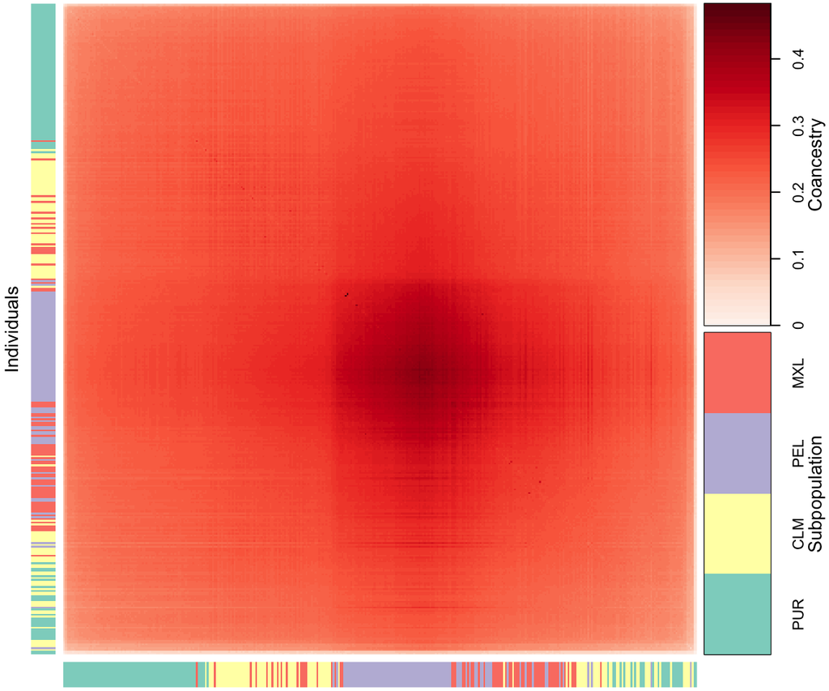

```r
load("rdata/coanc_os.rda")
load("rdata/fam.rda")

# We plot the individual-level coancestry
subpop_order <- c('PUR', 'CLM', 'PEL', 'MXL')
n_subpops      <- length(subpop_order)
colors_subpops <- RColorBrewer::brewer.pal(n_subpops, "Set3")
fam$col        <- colors_subpops[match(fam$fam, subpop_order)]

par(mar = c(0, 0, 0, 0) + 0.2)

layout(rbind(c(3, 1, 2),
             c(3, 1, 5),
             c(0, 4, 0)),
       widths  = c(0.05,   1,  0.2),
       heights = c(0.5,  0.5, 0.05))

popkin::plot_popkin(kinship = coanc_os, layout_add = FALSE, leg_cex = 0.8, ylab = '', leg_title = "Coancestry")

plot_colors_subpops(fam$col, y = TRUE)

mtext('Individuals', side = 2, line = 0.5, xpd = NA, cex = 0.8)

plot_colors_subpops(fam$col)

par(mar = c(0, 0, 0, 3) + 0.2)
legend_color_categories(colors = colors_subpops, categories = subpop_order, label = 'Subpopulation', cex_label = 0.8)
```

# 3 Estimating admixture proportions

The following chunk of the codes estimates the admixture proportions $\boldsymbol{Q}$ from genotypes. We first estimate the individual specific allele frequencies $\boldsymbol{\Pi}$ using the `est_p_indiv` function in the `superadmixture` package. We then estimate $\boldsymbol{Q}$ by decomposing $\boldsymbol{\Pi}$ with `factor_p_indiv` function in the `superadmixture` package. It takes hours to run the following codes, so we’re not running here.

```r
for (k_antepops in 2:15) {
    # estimate individual-specific allele frequencies
    obj <- est_p_indiv(X, k_antepops, loci_on_cols = TRUE)
    p_indiv <- obj$p_indiv
    rowspace <- obj$rowspace

    # estimate admix_props by decomposing individual-specific allele frequencies
    obj <- factor_p_indiv(p_indiv = p_indiv,
                          rowspace = rowspace,
                          k_antepops = k_antepops,
                          init_method = "rowspace",
                          verbose = TRUE,
                          max_iters = 1000,
                          tol = 1e-4)

    # save admixture proportions
    Q_hat <- obj$Q_hat
    dir.create(file.path("rdata", "Q_hat"), showWarnings = FALSE)
    save(Q_hat, file = paste0("rdata/Q_hat/", k_antepops, ".rda"))
}
```

# 4 Selecting number of antecedent populations

The following chunk of the codes calculates the p-values of structured Hardy-Weinberg Equilibrium test (sHWE) and plots the relationship between the negative entropy of the sHWE p-values and $K$. It takes hours to run the following codes, so we’re not running here.

```r
for (k_antepops in 2:15) {
    # estimate `rowspace`, an input for sHWE function
   rowspace <- est_p_indiv(X, k_antepops, loci_on_cols = TRUE, rowspace_only = TRUE)

   # perform sHWE test
   pvals <- sHWE(X, k_antepops, loci_on_cols = TRUE, rowspace = rowspace)
   save(pvals, file = paste0("rdata/sHWE/", k_antepops, ".rda"))
}

neg_entropy <- c()
for (k_antepops in 2:15) {
    load(paste0("rdata/sHWE/", k_antepops, ".rda"))
    neg_entropy <- c(neg_entropy, calc_neg_entropy(pvals))
}
save(neg_entropy, file = "rdata/neg_entropy.rda")
```

We visualize the relationship between $K$ and the negative entropy of sHWE p-values.

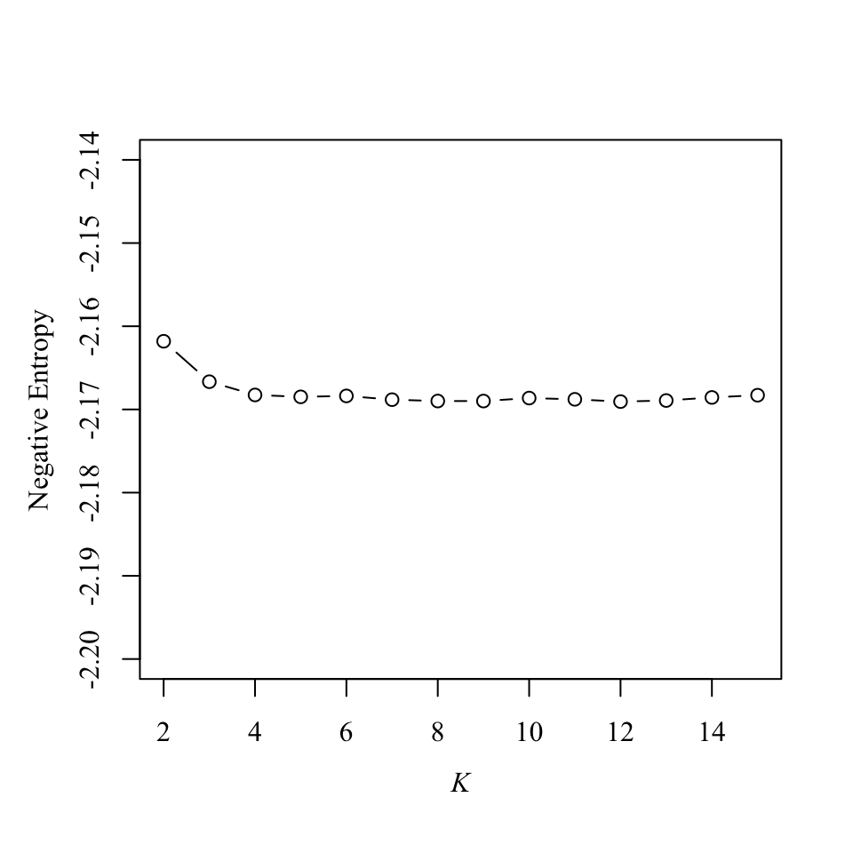

```r
load("rdata/neg_entropy.rda")
plot(2:15, neg_entropy, ylim = c(-2.2, -2.14), xlab = "", ylab = "", type = "b", family="Times New Roman")
mtext(latex2exp::TeX(r"(\textit{$K$})"), side = 1, col = "black", line = 2.5, family="Times New Roman", pch = 10)
mtext("Negative Entropy", side = 2, line = 2.5, col = "black",  family="Times New Roman")
```

We select $K = 3$ according to this plot.

# 5 Estimating antecedent populations coancestry

After obtaining individual-level coancestry $\boldsymbol{\Theta}$ and admixture proportions $\boldsymbol{Q}$, we can use the function `est_coanc` to estimate population coancestry under the super admixture and standard admixture.

```r
load("rdata/coanc_os.rda")
load("rdata/Q_hat/3.rda")

coanc_antepops_sup <- est_coanc(coanc_os, Q_hat, model = "super")
coanc_antepops_std <- est_coanc(coanc_os, Q_hat, model = "standard")
```

We then compute the corresponding individual-level coancestry under the super admixture and standard admixture.

```r
coanc_sup <- t(Q_hat) %*% coanc_antepops_sup %*% Q_hat
coanc_std <- t(Q_hat) %*% coanc_antepops_std %*% Q_hat
```

# 6 Visualization

We can visualize the coancestry of antecedent populations `coanc_antepops_sup` and admixture proportions `Q_hat` using the helper functions `get_seq_colors`, `plot_tree`, `barplot_admix` and `heatmap_coanc_antepops` we provide.

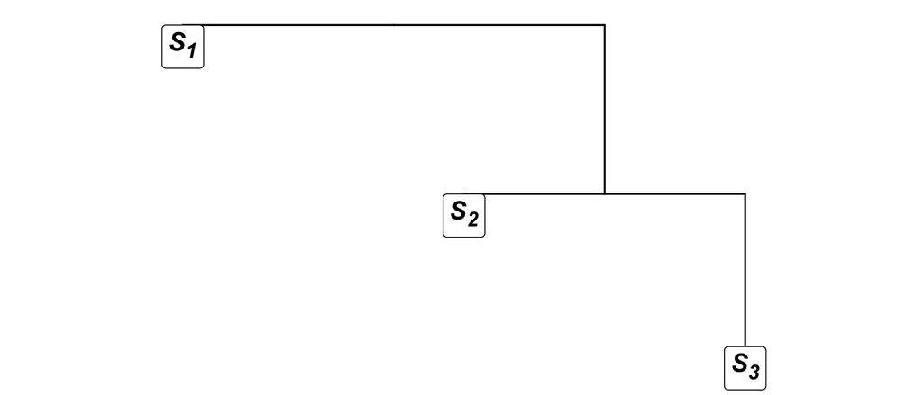

```r
# reorder antecedent populations in the ascending order of coancestry
index <- order(diag(coanc_antepops_sup))
Q_hat <- Q_hat[index, ]
coanc_antepops_sup <- coanc_antepops_sup[index, index]
k_antepops <- 3

# label antecedent populations
colnames(coanc_antepops_sup) <- rownames(coanc_antepops_sup) <- paste0("S", 1:k_antepops)

# fit tree
tree <- bnpsd::fit_tree(coanc_antepops_sup)

# plot an uncolorred tree
plot_tree(tree)
```

We decide to color the populations $S_1$, $S_2$ and $S_3$ by light red, red and dark red. We can pick a sequence of `Reds` by using the `get_seq_colors()` function and its returned value can be used to specify the coloring scheme for `plot_tree()` function.

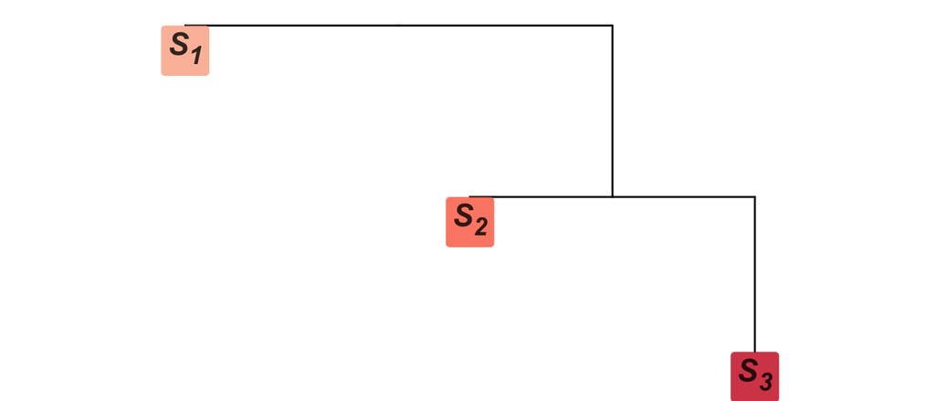

```r
colors <- get_seq_colors("Reds", k_antepops)
names(colors) <- paste0("S", 1:k_antepops)
fig_tree <- plot_tree(tree, colors = colors, font_size = 17)
fig_tree
```

We can visualize admixture proportions `Q_hat` using the `barplot_admix` function.

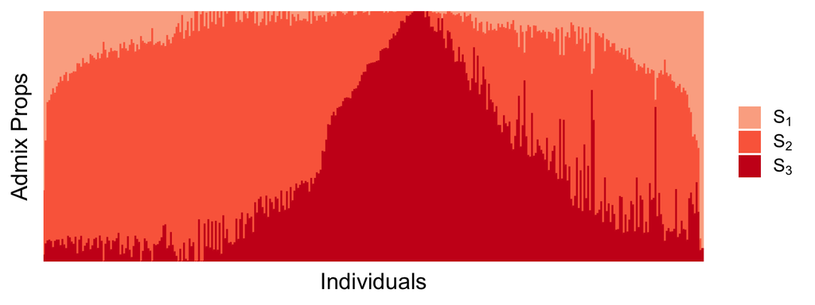

```r
fig_admix <- barplot_admix(Q_hat, colors = colors, base_size = 16)
fig_admix
```

We define a function called to plot the sub-population label of the data.

```r
barplot_subpops <- function(subpops, colors = NULL, subpop_order = NULL, base_size = 14) {

    data <- tibble::as_tibble(model.matrix(~value-1, data=tibble::as_tibble(subpops))) %>%
        dplyr::mutate(idx = 1:dplyr::n()) %>%
        tidyr::pivot_longer(!idx, names_to = "subpop", values_to = "indicator") %>%
        dplyr::mutate(subpop = stringr:::str_remove(subpop, "value"))

    if (! is.null(subpop_order))
        data <- data[order(factor(data$subpop, levels = subpop_order)), ]

    # create colors
    if (! is.null(colors)) {
        if (any(sort(as.character(names(colors))) != sort(as.character(unique(data$subpop)))))
             stop("`names(colors)` should match `unique(data$subpop)`")
    } else {
        subpop <- unique(data$subpop)
        k_subpops <- length(subpop)
        colors <- get_seq_colors("Set3", k_subpops)
        names(colors) <- subpop
    }

    # plot the population membership of each individual
    p <- ggplot2::ggplot(data, ggplot2::aes(x = idx, y = indicator, fill = subpop, col = subpop)) +
        ggplot2::geom_bar(stat = 'identity', linewidth = 0.2) +
        ggplot2::scale_fill_manual( values = colors) +
        ggplot2::scale_color_manual(values = colors) +
        ggplot2::scale_x_continuous(expand = c(0, 0)) +
        ggplot2::scale_y_continuous(expand = c(0, 0)) +
        ggplot2::theme_bw(base_size = base_size) +
        ggplot2::theme(panel.border = ggplot2::element_blank(),
                       legend.title = ggplot2::element_blank(),
                       axis.text    = ggplot2::element_blank(),
                       axis.title   = ggplot2::element_blank(),
                       axis.ticks   = ggplot2::element_blank(),
                       axis.line    = ggplot2::element_line(colour = "lightgrey", linewidth = 0.01))
    return(p)
}
```

```r
fig_subpops <- barplot_subpops(fam$fam)
```

We also can visualize the coancestry among antecedent populations by `heatmap_coanc_antepops`. We define the helper function `heatmap_coanc_antepops_wrapper` that returns a ggplot object of the heatmap.

```r
heatmap_coanc_antepops_wrapper <- function(coanc_antepops, tl.cex = 1.3, cl.cex = 1, tl.offset = 0.6) {
  superadmixture::heatmap_coanc_antepops(coanc_antepops, tl.cex = tl.cex, cl.cex = cl.cex, tl.offset = tl.offset)
  grab_grob <- function(){
    gridGraphics::grid.echo()
    grid::grid.grab()
  }
  p <- grab_grob()

 # save correlation matrix colors to a vector, then make coloured matrix grob transparent
 matrix.colors <- grid::getGrob(p, grid::gPath("square"), grep = TRUE)[["gp"]][["fill"]]
 p <- grid::editGrob(p, grid::gPath("square"), grep = TRUE, gp = grid::gpar(col = NA, fill = NA))

 # apply the saved colours to the underlying matrix grob
 p <- grid::editGrob(p, grid::gPath("symbols-rect-1"), grep = TRUE, gp = grid::gpar(fill = matrix.colors))

 # convert the background fill from white to transparent, while we are at it
 p <- grid::editGrob(p, grid::gPath("background"), grep = TRUE, gp = grid::gpar(fill = NA))
 p <- ggplotify::as.ggplot(p) + ggplot2::theme(plot.margin = unit(c(0, 0, 0, 0), "pt"))
 return(p)
}
```

```r
par(xpd = TRUE)
fig_coancestry <- heatmap_coanc_antepops_wrapper(coanc_antepops_sup, tl.cex = 1.3, tl.offset = 1)
```

```r
fig_coancestry <- fig_coancestry + theme(plot.margin = margin(0, 0, 0, 0, "pt"))
coancestry_lab <- ggplot() +
  annotate("text", x = 0.5, y = 0.5, size = 5.1, label = "Coancestry") +
  xlim(0, 1) +
  ylim(0, 1) +
  theme_void()
fig_coancestry <- ggarrange(fig_coancestry, coancestry_lab, ncol = 1, heights = c(1, 0.1))
```

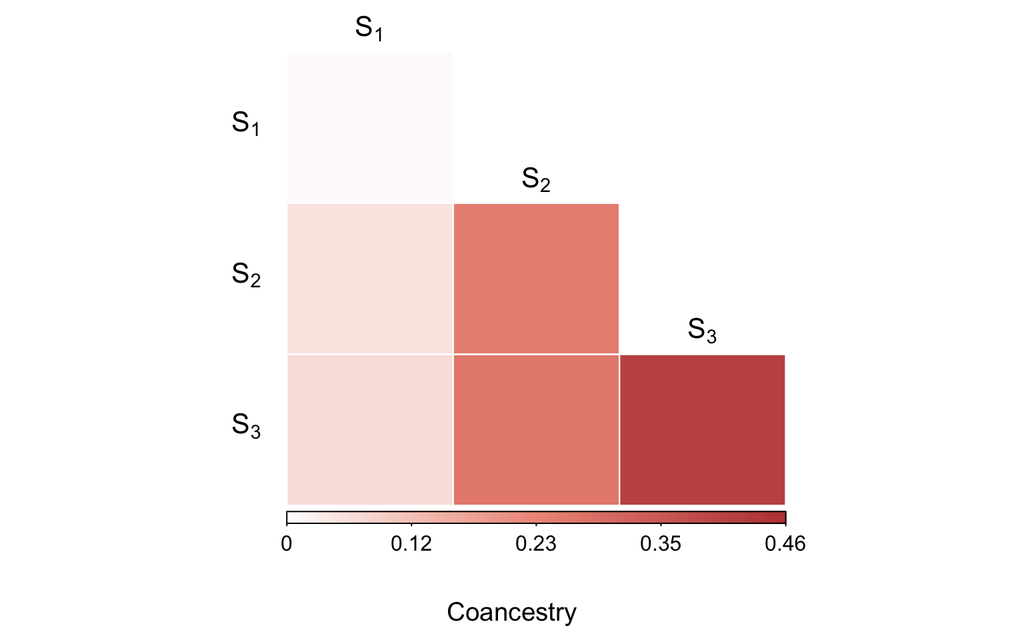

```r
fig_coancestry
```

We combine all plots.

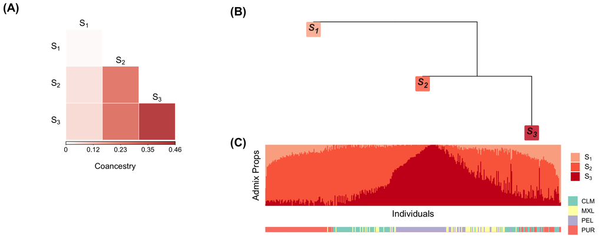

```r
# convert the legend of the admix plot as a ggplot object
legend_admix <- ggpubr::as_ggplot(cowplot::get_legend(fig_admix))

# suppress the legend in the admix plot
fig_admix    <- fig_admix + ggplot2::theme(legend.position = "none")

# convert the legend of the subpop plot as a ggplot object
legend_subpops <- ggpubr::as_ggplot(cowplot::get_legend(fig_subpops))

# suppress the legend in the subpop plot
fig_subpops    <- fig_subpops + ggplot2::theme(legend.position = "none")

# combine the admix plot and subpop plot
fig_admix_subpops    <- cowplot::plot_grid(fig_admix,
                            fig_subpops,
                            ncol = 1,
                            align = 'v',
                            axis = 'lr',
                            rel_heights = c(1, 0.18))

# combine the legends
legend_admix_subpops <- cowplot::plot_grid(legend_admix,
                            legend_subpops,
                            ncol = 1,
                            align = "v",
                            axis = 'l',
                            rel_heights = c(1, 1))
fig_legend_admix_subpops <- cowplot::plot_grid(
                            fig_admix_subpops,
                            legend_admix_subpops,
                            nrow = 1,
                            rel_widths = c(10, 1))


# combine plots of tree, admix props, subpops and coancestry
design <- "
  112
  113
  ##3
"

fig_coancestry + fig_tree + fig_legend_admix_subpops +
  patchwork::plot_layout(
            design = design,
            widths = c(0.7, 0.2, 1.4),
            heights = c(0.7, 0.2, 0.4)) +
  patchwork::plot_annotation(tag_levels = 'A', tag_prefix = '(', tag_suffix = ')') &
  ggplot2::theme(plot.tag = ggplot2::element_text(color = "black", size = 21, face = 'bold'))
```

# 7 Simulating genotypes from the structure of AMR

We can simulate genotypes using the double-admixture method with the `dbl_admixture` function. It takes about an hour to run the following codes, so we’re not running here.

```r
X <- as.matrix(X)
p_anc <- 0.5 * colMeans(X, na.rm = TRUE)
coanc_antepops <- round(coanc_antepops, 6)
X_sim <- dbl_admixture(p_anc, coanc_antepops, Q_hat, geno_only = TRUE)

## estimate kinship
obj         <- popkin::popkin_A(X_sim)
A_min   <- mean(sort(obj$A[lower.tri(obj$A)])[1:100])
kinship_sim_os  <- 1 - obj$A / A_min

## mapping kinship coefficients to coancestry coefficients
coanc_sim_os  <- popkin::inbr_diag(kinship_sim_os)
coanc_sim_os  <- ifelse(coanc_sim_os < 0, 0, coanc_sim_os)
save(coanc_sim_os,  file = "rdata/coanc_sim_os.rda")
```

We can also use NORTA method to simulate genotypes. It takes a few hours to run the following codes, so we’re not running here.

```r
X_sim_norta <- norta_approx(p_anc, coanc_antepops, Q_hat,
              geno_only = TRUE, parallel = TRUE, method = "numeric", tol = 1e-5, mc_cores = 20)

## estimate kinship
obj         <- popkin::popkin_A(X_sim_norta)
A_min   <- mean(sort(obj$A[lower.tri(obj$A)])[1:100])
kinship_sim_os_norta  <- 1 - obj$A / A_min

## mapping kinship coefficients to coancestry coefficients
coanc_sim_os_norta    <- popkin::inbr_diag(kinship_sim_os_norta)
coanc_sim_os_norta    <- ifelse(coanc_sim_os_norta < 0, 0, coanc_sim_os_norta)
save(coanc_sim_os_norta,   file = "rdata/coanc_sim_os_norta.rda")
```

We plot the individual-level coancestry.

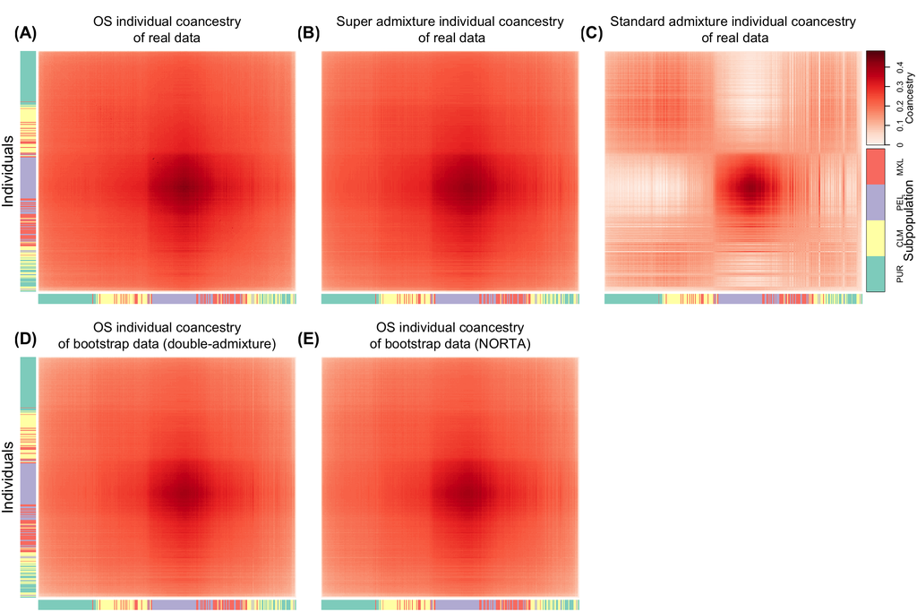

```r
load("rdata/coanc_sim_os.rda")
load("rdata/coanc_sim_os_norta.rda")

par(mar = c(0, 0, 0, 0) + 0.2)
layout(rbind(
   c(15, 20, 16, 21, 17, 22,  0),
   c( 8,  1,  0,  2,  0,  3,  6),
   c( 8,  1,  0,  2,  0,  3,  7),
   c( 0, 10,  0, 11,  0, 12,  0),
   c(18, 23, 19, 24,  0,  0,  0),
   c( 9,  4,  0,  5,  0,  0,  0),
   c( 0, 13,  0, 14,  0,  0,  0)),
  heights = c(0.2, 0.4, 0.6, 0.05, 0.2, 1, 0.05),
  widths  = c(0.08, 1, 0.08, 1, 0.08, 1, 0.2))

coanc_sim_os       <- (coanc_sim_os - 1) * (1 - min(coanc_sup)) + 1
coanc_sim_os_norta <- (coanc_sim_os_norta - 1) * (1 - min(coanc_sup)) + 1
# We truncate the large entries of `coanc_std`
# ccoanc_std  <- ifelse(coanc_std > max(coanc_os), max(coanc_os), coanc_std)

popkin::plot_popkin(kinship = list(coanc_os, coanc_sup, coanc_std, coanc_sim_os, coanc_sim_os_norta),
                    layout_add = FALSE,
                    leg_cex = 0.8,
                    labs_text = FALSE,
                    labs_lwd = 0.1,
                    labs = fam$subpop,
                    ylab = '',
                    leg_title = "Coancestry",
                    panel_letters = NULL)

par(mar = c(0, 0, 0, 3) + 0.2)
legend_color_categories(colors = colors_subpops, categories = subpop_order, label = 'Subpopulation', cex_label = 1)

par(mar = c(0.2, 0.5, 0.2, 0))
plot_colors_subpops(fam$col, y = TRUE)
mtext('Individuals', side = 2, line = 0.5, xpd = NA, cex = 1.2)

par(mar = c(0.2, 0.5, 0.2, 0))
plot_colors_subpops(fam$col, y = TRUE)
mtext('Individuals', side = 2, line = 0.5, xpd = NA, cex = 1.2)

par(mar = c(0.2, 0.2, 0, 0.2))
plot_colors_subpops(fam$col)
par(mar = c(0.2, 0.2, 0, 0.2))
plot_colors_subpops(fam$col)
par(mar = c(0.2, 0.2, 0, 0.2))
plot_colors_subpops(fam$col)
par(mar = c(0.2, 0.2, 0, 0.2))
plot_colors_subpops(fam$col)
par(mar = c(0.2, 0.2, 0, 0.2))
plot_colors_subpops(fam$col)

par(mar = c(0, 0, 0, 0))
plot(c(0, 1), c(0, 1), ann = F, bty = 'n', type = 'n', xaxt = 'n', yaxt = 'n')
text(0.5, 0.3, "(A)", cex = 2, xpd = TRUE, font = 2)

par(mar = c(0, 0, 0, 0))
plot(c(0, 1), c(0, 1), ann = F, bty = 'n', type = 'n', xaxt = 'n', yaxt = 'n')
text(0.5, 0.3, "(B)", cex = 2, xpd = TRUE, font = 2)

par(mar = c(0, 0, 0, 0))
plot(c(0, 1), c(0, 1), ann = F, bty = 'n', type = 'n', xaxt = 'n', yaxt = 'n')
text(0.5, 0.3, "(C)", cex = 2, xpd = TRUE, font = 2)

par(mar = c(0, 0, 0, 0))
plot(c(0, 1), c(0, 1), ann = F, bty = 'n', type = 'n', xaxt = 'n', yaxt = 'n')
text(0.5, 0.3, "(D)", cex = 2, xpd = TRUE, font = 2)

par(mar = c(0, 0, 0, 0))
plot(c(0, 1), c(0, 1), ann = F, bty = 'n', type = 'n', xaxt = 'n', yaxt = 'n')
text(0.5, 0.3, "(E)", cex = 2, xpd = TRUE, font = 2)



plot(c(0, 1), c(0, 1), ann = F, bty = 'n', type = 'n', xaxt = 'n', yaxt = 'n')
text(0.5, 0.4, "OS individual coancestry\nof real data", cex = 1.6)

plot(c(0, 1), c(0, 1), ann = F, bty = 'n', type = 'n', xaxt = 'n', yaxt = 'n')
text(0.5, 0.4, "Super admixture individual coancestry\n of real data", cex = 1.6)

plot(c(0, 1), c(0, 1), ann = F, bty = 'n', type = 'n', xaxt = 'n', yaxt = 'n')
text(0.5, 0.4, "Standard admixture individual coancestry\n of real data", cex = 1.6)

plot(c(0, 1), c(0, 1), ann = F, bty = 'n', type = 'n', xaxt = 'n', yaxt = 'n')
text(0.5, 0.4, "OS individual coancestry\nof bootstrap data (double-admixture)", cex = 1.6)

plot(c(0, 1), c(0, 1), ann = F, bty = 'n', type = 'n', xaxt = 'n', yaxt = 'n')
text(0.5, 0.4, "OS individual coancestry\nof bootstrap data (NORTA)", cex = 1.6)
```

# 8 Confirming significant hypothesis tests of standard admixture versus super admixture

We perform the significance test of coancestry among antecedent populations to compare the model fit between standard admixture versus super admixture. The following chunk of codes is used to generate the null distribution of the test statistics $U$. It should be noted that it takes days to run this chunk of code. We submit each iteration as a separate cluster job to speed up (not show here). Therefore, we’re just showing the code but not running it. We provide the pre-computed null test statistics in the file `rdata/test_stats0.rda`.

```r
for (task_id in 1:1000) {
  ## compute null test statistics
  inbr_antepops <- diag(est_coanc(coanc_os, Q_hat, model = "standard"))

  ## compute null
  test_stats0 <- compute_null(p_anc, Q_hat, inbr_antepops, verbose = TRUE)

  # save results
  dir.create(file.path("rdata", "test_stat0"), showWarnings = FALSE)
  save(test_stat0, file = paste0("rdata/test_stat0/", task_id, ".rda"))
}

test_stats0 <- c()
for (task_id in 1:1000) {
  load(paste0("rdata/test_stat0/", task_id, ".rda"))
  test_stats0 <- c(test_stats0, test_stat0)
}
save(test_stats0, file = "rdata/test_stats0.rda")
```

We plot the distribution of null test statistics and label our observed test statistics.

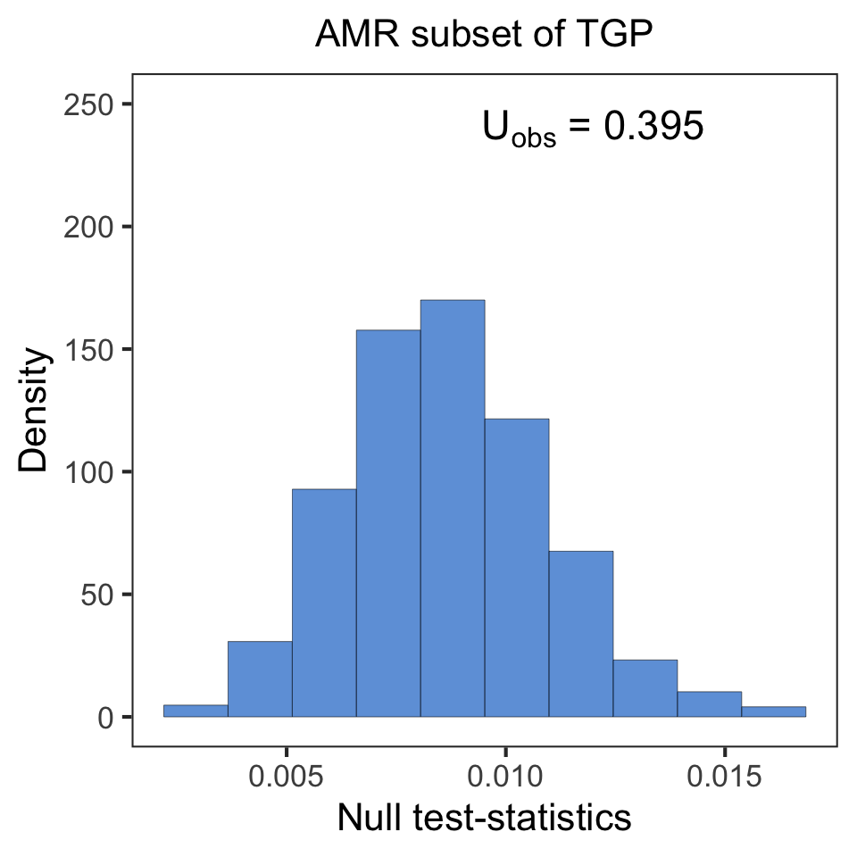

```r
load("rdata/test_stats0.rda")
load("rdata/coanc_os.rda")
load("rdata/Q_hat/3.rda")

coanc_antepops_sup <- est_coanc(coanc_os, Q_hat, model = "super")
coanc_antepops_std <- est_coanc(coanc_os, Q_hat, model = "standard")

test_stat1 <- norm(coanc_antepops_sup - coanc_antepops_std, "F")
p <- data.frame(test_stats0 = test_stats0) %>%
     ggplot(data, mapping = aes(x = test_stats0)) +
        geom_histogram(aes(y =..density..),
                 fill  = "dodgerblue3",
                 bins  = 10,
                 binwidth = NULL,
                 color = "black",
                 alpha = 0.7,
                 size  = 0.1) +
    labs(x = latex2exp::TeX(r"(Null test-statistics)"), y='Density') +
    scale_y_continuous(limits = c(0, 250)) +
    theme_bw(base_size = 16) +
    ggtitle("AMR subset of TGP") +
    theme(panel.grid.major = element_blank(),
          panel.grid.minor = element_blank(),
    plot.title = element_text(hjust = 0.5, size=16)) +
    annotate("text", x = 0.012, y = 240, size = 6, label = latex2exp::TeX(sprintf("$U_{obs}$ = %.3f", test_stat1)))
p
```